# R Notebook

# Basic Regression

```r
library(tidyverse)
library(moderndive)
library(skimr)
library(gapminder)
```

## One numerical explanatory variable

Examine the relationship between a professor’s ratemyprofessor.com rating as a function of their beauty score. We can model this relationship using simple linear regression with a single explanatory variable, beauty, ($x$), and a single numerical outcome variable: rating ($y$).

### EDA of beauty average and score

```r
evals_ch5 <- evals %>%
  select(ID, score, bty_avg, age)

glimpse(evals_ch5)
```

```
Observations: 463
Variables: 4
$ ID      <int> 1, 2, 3, 4, 5, 6, 7, 8, 9, 10, 11, 12, 13, 14…
$ score   <dbl> 4.7, 4.1, 3.9, 4.8, 4.6, 4.3, 2.8, 4.1, 3.4, …
$ bty_avg <dbl> 5.000, 5.000, 5.000, 5.000, 3.000, 3.000, 3.0…
$ age     <int> 36, 36, 36, 36, 59, 59, 59, 51, 51, 40, 40, 4…
```

Calculate univariate summary stats with `summarize`

```r
evals_ch5 %>%
  summarize(mean_bty_avg = mean(bty_avg),
            mean_score = mean(score),
            median_bty_avg = median(bty_avg),
            median_score = median(score))
```

| mean_bty_avg | mean_score | median_bty_avg | median_score |
| --- | --- | --- | --- |
| 4.417844 | 4.17473 | 4.333 | 4.3 |

Calculate univariate summary stats with `skimr`

```r
evals_ch5 %>% select(score, bty_avg) %>% skim()
```

```
── Data Summary ────────────────────────
                           Values
Name                       Piped data
Number of rows             463
Number of columns          2
_______________________
Column type frequency:
  numeric                  2
________________________
Group variables            None

── Variable type: numeric ──────────────────────────────────────
  skim_variable n_missing complete_rate  mean    sd    p0   p25
1 score                 0             1  4.17 0.544  2.3   3.8
2 bty_avg               0             1  4.42 1.53   1.67  3.17
    p50   p75  p100 hist
1  4.3    4.6  5    ▁▁▅▇▇
2  4.33   5.5  8.17 ▃▇▇▃▂
```

Use `cor` to calculate $r$, a bivariate summary stat:

```r
evals_ch5 %>%
  summarize(correlation = cor(score, bty_avg))
```

| correlation |
| --- |
| 0.1871424 |

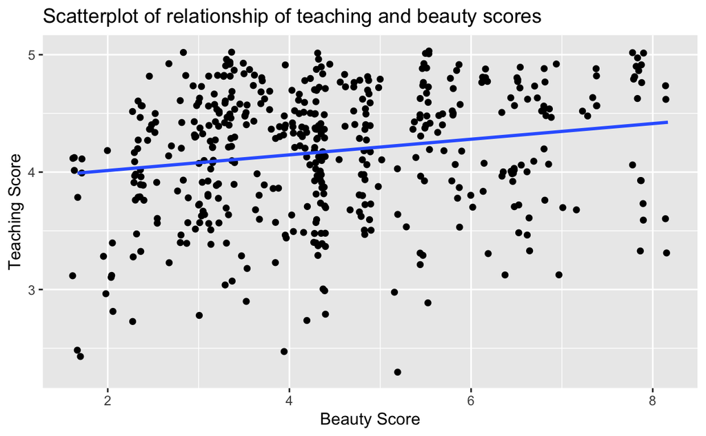

```r
evals_ch5 %>%
  ggplot(aes(x = bty_avg, y = score)) +
    geom_jitter() +
    labs(x = "Beauty Score",
         y = "Teaching Score",
         title = "Scatterplot of relationship of teaching and beauty scores") +
    geom_smooth(method = "lm", se = FALSE)
```

### EDA of age and score

```r
evals_ch5 %>% select(age, score) %>% skim()
```

```
── Data Summary ────────────────────────
                           Values
Name                       Piped data
Number of rows             463
Number of columns          2
_______________________
Column type frequency:
  numeric                  2
________________________
Group variables            None

── Variable type: numeric ──────────────────────────────────────
  skim_variable n_missing complete_rate  mean    sd    p0   p25
1 age                   0             1 48.4  9.80   29    42
2 score                 0             1  4.17 0.544   2.3   3.8
    p50   p75  p100 hist
1  48    57      73 ▅▆▇▆▁
2   4.3   4.6     5 ▁▁▅▇▇
```

[output not shown]

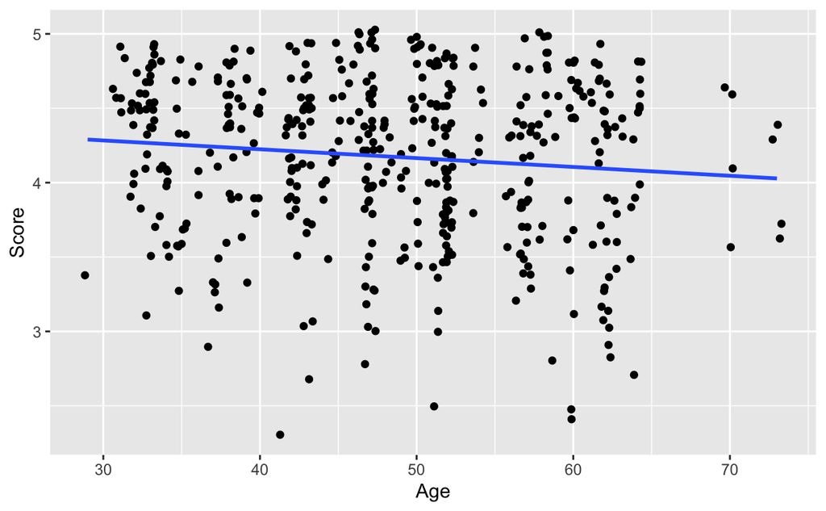

```r
evals_ch5 %>%
  ggplot(aes(x = age, y = score)) +
    geom_jitter() +
    labs(x = "Age",
         y = "Score") +
    geom_smooth(method = "lm", se = FALSE)
```

### Simple linear regression

$$\hat{y} = b_0 + b_1 \cdot x$$

```r
library(broom)
score_model <- lm(score ~ bty_avg, data = evals_ch5)
tidy(score_model)
```

| term | estimate | std.error | statistic | p.value |
| --- | --- | --- | --- | --- |
| (Intercept) | 3.88033795 | 0.07614297 | 50.961212 | 1.561043e-191 |
| bty_avg | 0.06663704 | 0.01629115 | 4.090382 | 5.082731e-05 |

$$\widehat{score} = b_0 + b_{bty\_avg} \cdot \textrm{bty_avg}$$
$$= 3.88 + 0.067 \cdot \textrm{bty_avg}$$

```r
age_model <- lm(score ~ age, data = evals_ch5)
tidy(age_model)
```

| term | estimate | std.error | statistic | p.value |
| --- | --- | --- | --- | --- |
| (Intercept) | 4.461932354 | 0.126778499 | 35.194709 | 1.052874e-132 |
| age | -0.005938225 | 0.002569157 | -2.311351 | 2.125363e-02 |

$$= 4.46 - 0.006 \cdot \textrm{age}$$
#### Residuals

[output not shown]

[output cut: 453 more lines]

## Regression with one categorical explanatory variable

### EDA of mean life expectancy by continent

Examine the relationship between continent and life expectancy.

```r
gapminder2007 <- gapminder %>%
  filter(year == 2007) %>%
  select(country, lifeExp, continent, gdpPercap)

glimpse(gapminder2007)
```

```
Observations: 142
Variables: 4
$ country   <fct> Afghanistan, Albania, Algeria, Angola, Arg…
$ lifeExp   <dbl> 43.828, 76.423, 72.301, 42.731, 75.320, 81…
$ continent <fct> Asia, Europe, Africa, Africa, Americas, Oc…
$ gdpPercap <dbl> 974.5803, 5937.0295, 6223.3675, 4797.2313,…
```

```r
gapminder2007 %>%
  select(lifeExp, continent) %>%
  skim()
```

```
── Data Summary ────────────────────────
                           Values
Name                       Piped data
Number of rows             142
Number of columns          2
_______________________
Column type frequency:
  factor                   1
  numeric                  1
________________________
Group variables            None

── Variable type: factor ──────────────────────────────────────
  skim_variable n_missing complete_rate ordered n_unique
1 continent             0             1 FALSE          5
  top_counts
1 Afr: 52, Asi: 33, Eur: 30, Ame: 25

── Variable type: numeric ─────────────────────────────────────
  skim_variable n_missing complete_rate  mean    sd    p0   p25
1 lifeExp               0             1  67.0  12.1  39.6  57.2
    p50   p75  p100 hist
1  71.9  76.4  82.6 ▂▃▃▆▇
```

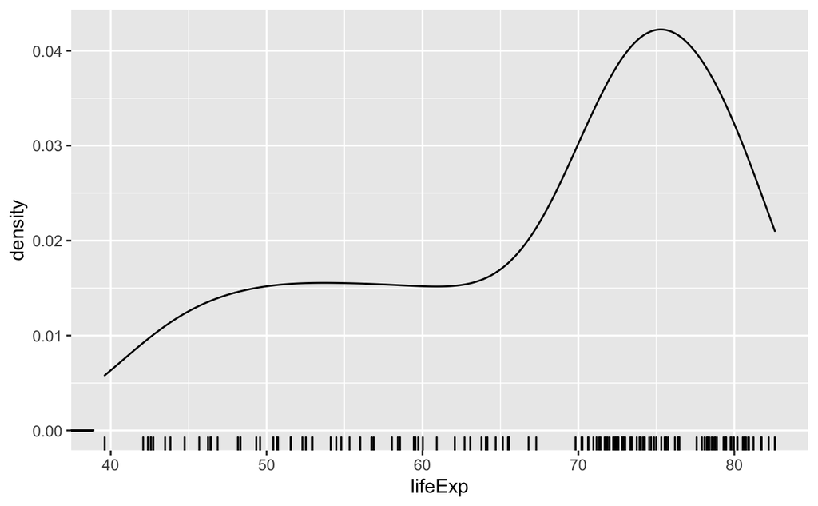

```r
gapminder2007 %>%
  ggplot(aes(x = lifeExp)) +
    geom_density() +
    geom_rug(aes(x = lifeExp, y = 0), position = position_jitter(height = 0))
```

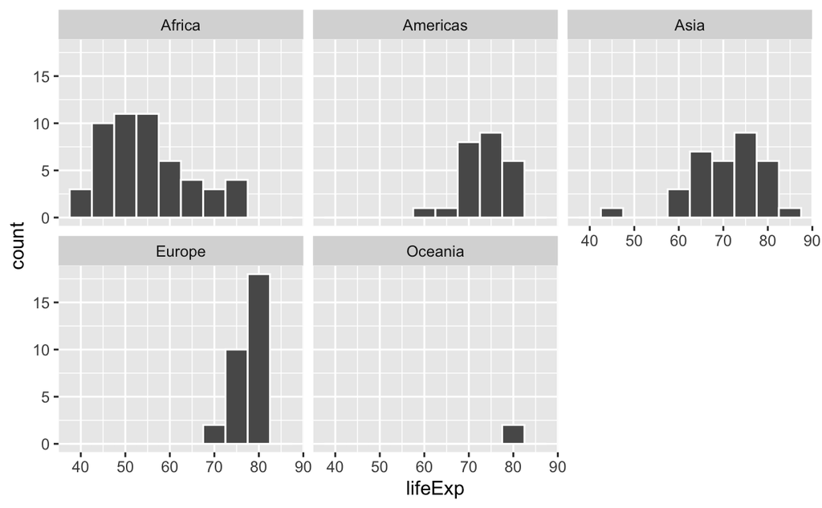

```r
gapminder2007 %>%
  ggplot(aes(x = lifeExp)) +
    geom_histogram(binwidth = 5, color = 'white') +
    facet_wrap(~continent)
```

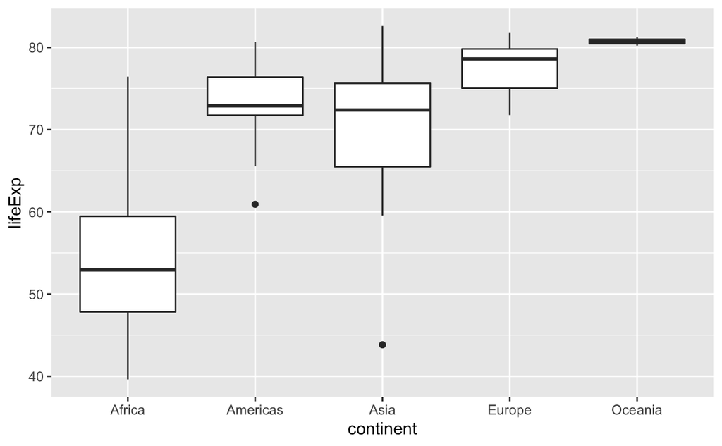

```r
gapminder2007 %>%
  ggplot(aes(x = continent, y = lifeExp)) +
    geom_boxplot()
```

```r
gapminder2007 %>% group_by(continent) %>% select(continent, lifeExp) %>% skim()
```

```
── Data Summary ────────────────────────
                           Values
Name                       Piped data
Number of rows             142
Number of columns          2
_______________________
Column type frequency:
  numeric                  1
________________________
Group variables            continent

── Variable type: numeric ─────────────────────────────────────
  skim_variable continent n_missing complete_rate  mean    sd
1 lifeExp       Africa            0             1  54.8 9.63
2 lifeExp       Americas          0             1  73.6 4.44
3 lifeExp       Asia              0             1  70.7 7.96
4 lifeExp       Europe            0             1  77.6 2.98
5 lifeExp       Oceania           0             1  80.7 0.729
     p0   p25   p50   p75  p100 hist
1  39.6  47.8  52.9  59.4  76.4 ▇▇▇▂▃
2  60.9  71.8  72.9  76.4  80.7 ▁▁▇▇▅
3  43.8  65.5  72.4  75.6  82.6 ▁▁▅▇▅
4  71.8  75.0  78.6  79.8  81.8 ▃▅▂▇▇
5  80.2  80.5  80.7  81.0  81.2 ▇▁▁▁▇
```

What are the various mean life expectancy values relative to Africa’s?

```r
gapminder2007 %>%
  group_by(continent) %>%
  summarize(mean = mean(lifeExp)) %>%
  mutate(`Difference vs Africa` = mean - .[[1,2]])
```

| continent | mean | Difference vs Africa |
| --- | --- | --- |
| Africa | 54.80604 | 0.00000 |
| Americas | 73.60812 | 18.80208 |
| Asia | 70.72848 | 15.92245 |
| Europe | 77.64860 | 22.84256 |
| Oceania | 80.71950 | 25.91346 |

### EDA of GDP per Capita by continent

```r
gapminder2007 %>%
  select(continent, gdpPercap) %>%
  skim()
```

```
── Data Summary ────────────────────────
                           Values
Name                       Piped data
Number of rows             142
Number of columns          2
_______________________
Column type frequency:
  factor                   1
  numeric                  1
________________________
Group variables            None

── Variable type: factor ──────────────────────────────────────
  skim_variable n_missing complete_rate ordered n_unique
1 continent             0             1 FALSE          5
  top_counts
1 Afr: 52, Asi: 33, Eur: 30, Ame: 25

── Variable type: numeric ─────────────────────────────────────
  skim_variable n_missing complete_rate   mean     sd    p0
1 gdpPercap             0             1 11680. 12860.  278.
    p25   p50    p75   p100 hist
1 1625. 6124. 18009. 49357. ▇▂▁▂▁
```

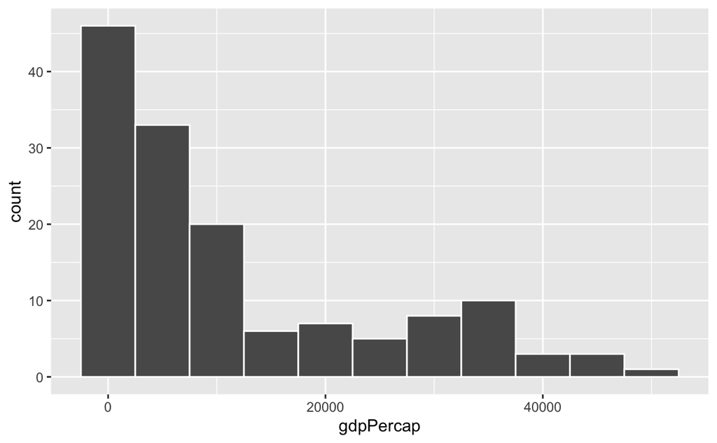

```r
gapminder2007 %>%
  ggplot(aes(x = gdpPercap)) +
    geom_histogram(binwidth = 5000, color = 'white')
```

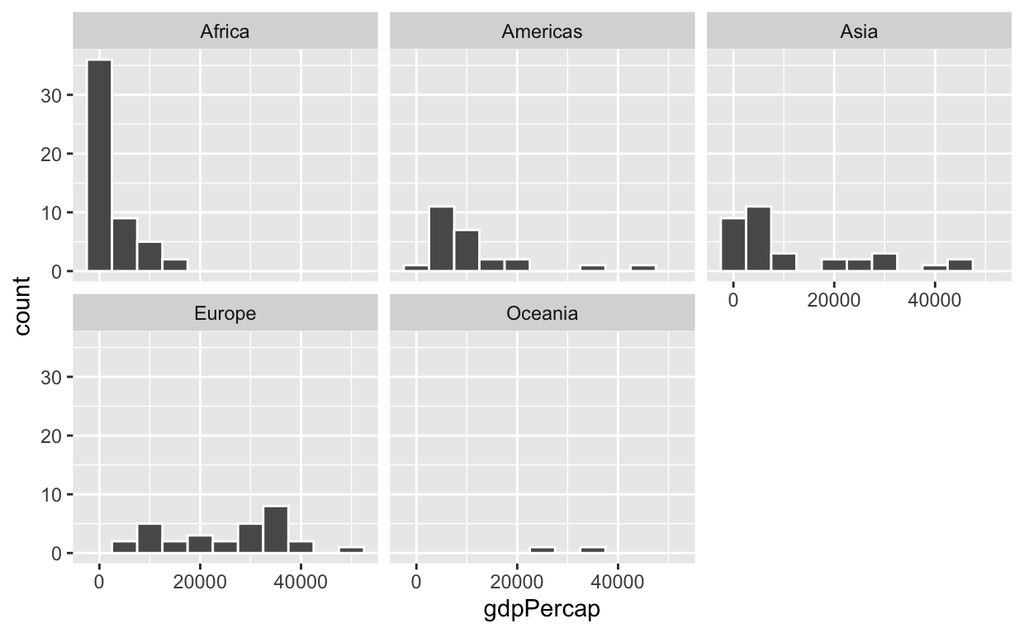

```r
gapminder2007 %>%
  ggplot(aes(x = gdpPercap)) +
    geom_histogram(binwidth = 5000, color = 'white') +
    facet_wrap(~ continent)
```

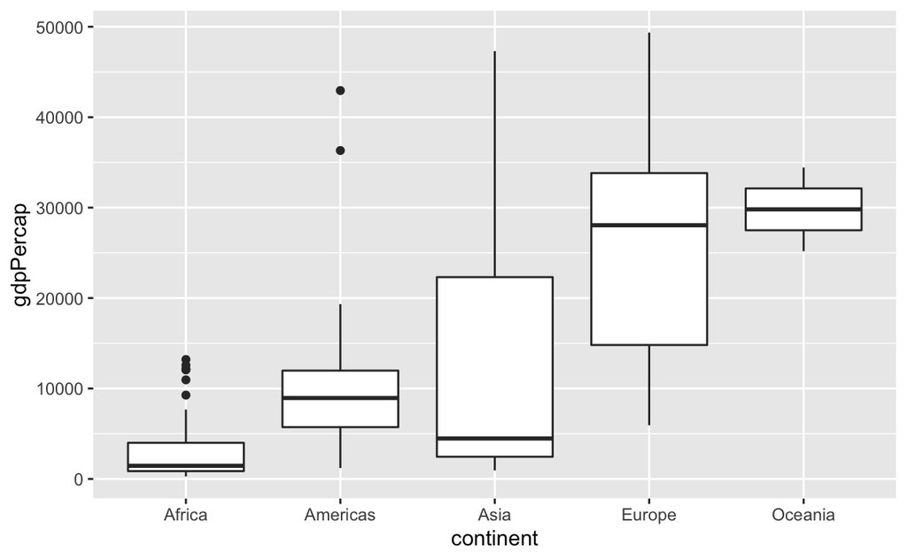

```r
gapminder2007 %>%
  ggplot(aes(x = continent, y = gdpPercap)) +
    geom_boxplot()
```

```r
gapminder2007 %>%
  group_by(continent) %>%
  summarize(`mean GDP per capita` = mean(gdpPercap)) %>%
  mutate(`Difference vs. Africa` = `mean GDP per capita` - .[[1,2]])
```

| continent | mean GDP per capita | Difference vs. Africa |
| --- | --- | --- |
| Africa | 3089.033 | 0.000 |
| Americas | 11003.032 | 7913.999 |
| Asia | 12473.027 | 9383.994 |
| Europe | 25054.482 | 21965.449 |
| Oceania | 29810.188 | 26721.156 |

### Creating a regression model

Because the explanatory variable here (continent) is categorical, it can’t go directly into the model. Rather, the baseline becomes the intercept, and the estimates for the remaining data are offsets relative to the baseline.

```r
lifeExp_model <- lm(lifeExp ~ continent, data = gapminder2007)
tidy(lifeExp_model)
```

| term | estimate | std.error | statistic | p.value |
| --- | --- | --- | --- | --- |
| (Intercept) | 54.80604 | 1.025447 | 53.446016 | 1.230613e-93 |
| continentAmericas | 18.80208 | 1.799652 | 10.447623 | 3.744223e-19 |
| continentAsia | 15.92245 | 1.645756 | 9.674850 | 3.413979e-17 |
| continentEurope | 22.84256 | 1.695350 | 13.473655 | 7.099697e-27 |
| continentOceania | 25.91346 | 5.328377 | 4.863293 | 3.122425e-06 |

Wriring the equation for regression with a single categorical explanatory variable requires introducing the concept of an indicator function. An indicator function, $1_A(x)$ is one that takes the value $1$ if $x$ is in $A$ and $0$ otherwise. So $1_{\textrm{Amer}}(x)$ would be $1$ if $x$ were in the Americas and $0$ otherwise. It’s basically a dummy variable.

With that in mind, the equation for the regression line here is just:

$$\hat{y} = \widehat{\textrm{life exp}} =
b_0 + b_{\textrm{Amer}}(x) \cdot 1_{\textrm{Amer}}(x) +
b_{\textrm{Euro}}(x) \cdot 1_{\textrm{Euro}}(x) + \\
b_{\textrm{Asia}}(x) \cdot 1_{\textrm{Asia}}(x) +
b_{\textrm{Ocean}}(x) \cdot 1_{\textrm{Ocean}}(x)$$

```r
(lifeExp_regression_table <- augment_columns(lifeExp_model, gapminder2007) %>%
  select(country, continent, lifeExp, .fitted, .resid))
```

[output not shown]

```r
lifeExp_regression_table %>%
  arrange(.resid) %>%
  head(5)
```

[output not shown]

```r
lifeExp_regression_table %>%
  arrange(desc(.resid)) %>%
  head(5)
```

[output not shown]

### Model GDP Per Capita

```r
gdpPercap_model <- lm(gdpPercap ~ continent, data = gapminder2007)
tidy(gdpPercap_model)
```

[output not shown]

## Best Fit

```r
score_model %>%
  augment() %>%
  mutate(resid_squared = .resid^2) %>%
  summarise(sum_of_squared_residuals = sum(resid_squared))
```

| sum_of_squared_residuals |
| --- |
| 131.8684 |